# BRFSS Output Detail

### Overview

BRFSS data are survery responses over multiple years, where respondents answer questions that will give an indication on future health based on their behaviorial factors. This dataset is from 2011 until 2013.

### Breakdown of Data

Within a single Class, there are multiple Topics. An example of the topic and its associated questions are below:

```r
pa_class %>% select(Topic, Question) %>% distinct()
```

```
##                     Topic
## 1                Exercise
## 2 Physical Activity Index
## 3       Strength Activity
## 4        Aerobic Activity
##                                                                               Question
## 1               During the past month, did you participate in any physical activities?
## 2            Participated in 150 minutes or more of Aerobic Physical Activity per week
## 3                Participated Muscle Strengthening exercises more than twice  per week
## 4 Participated in enough Aerobic and Muscle Strengthening exercises to meet guidelines
```

Responses for these are either a yes or no for this topic, so can be broken down on a boolean basis. This allows for a simple proportion of YES answers giving a good representation of the overall response.

For some reason, there was only one question for Physical Activity asked in 2012. Below you can see the results broken out over year.

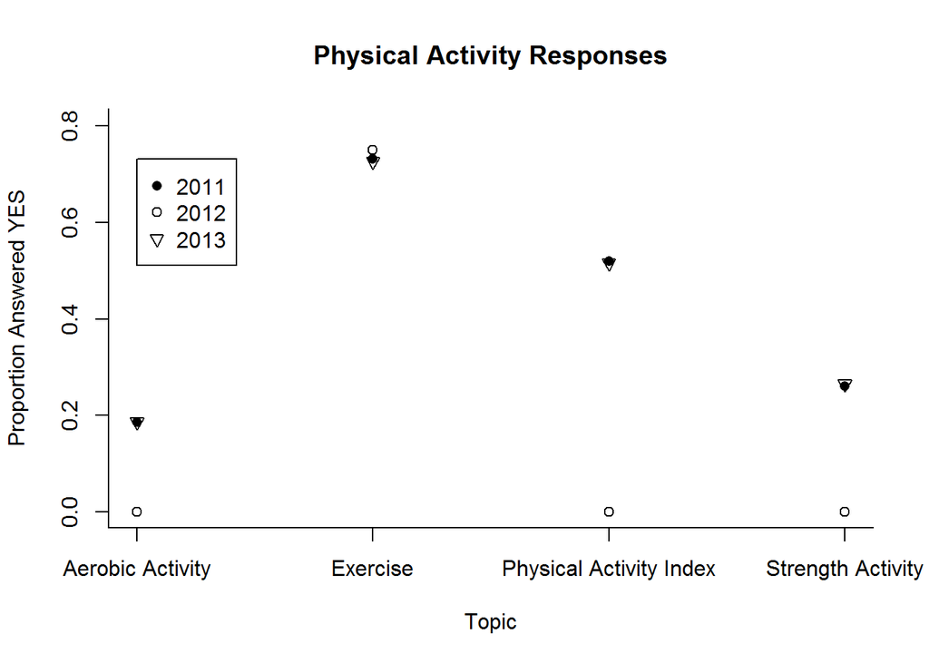

The above shows what proportion of respondents answered “YES.” The CDC has done work to further classify each category with its own data value. What this means is it calculates a proportion for the answer within the respective group. For example, if we were looking at the overall group for Exercise in Alaska, we would see the different data values, along with the respective high and low confidence limits. Let’s look at that below.

> During the past month, did you participate in any physical activities?

```
##   Year Response Sample_Size Data_value Confidence_limit_Low
## 1 2013      Yes        3294       77.7                 75.9
## 2 2013       No         981       22.3                 20.5
## 3 2012      Yes        3465       81.5                 79.9
## 4 2012       No         871       18.5                 16.8
## 5 2011      Yes        2573       78.0                 76.1
## 6 2011       No         776       22.0                 20.1
##   Confidence_limit_High Data_value_unit
## 1                  79.5               %
## 2                  24.1               %
## 3                  83.2               %
## 4                  20.1               %
## 5                  79.9               %
## 6                  23.9               %
```

### Final Remarks

Additional work can be done to break out how these changed over the years of response, and/or by state and age group. Additionally, there are multiple other Classes each having their own Topic that can lead to additional insight, and what constitutes a healthy individual.

Something of note - Work has been done to this dataset already to clean it up and tally the total number of respondents per category along with giving an estimate value for the response (given in %), with a low and high confidence limit to that number. Due to the fact that a significant amount of work has already been to ensure the data is clean, it brings in the question whether or not this dataset is suitable for a Capstone Project.